# Problem Set 2 - A+ team

Chu-Chun Ku, Yi-Ting Lee, Hsiang Lee

## Load the package

```r
library(haven)
library(dplyr)
library(knitr)
data <- read_dta("all.dta")
head(data)
```

```
## # A tibble: 6 × 15
##   agemo_mda cod_any cod_homicide cod_MVA cod_extother cod_external cod_internal
##       <dbl>   <dbl>        <dbl>   <dbl>        <dbl>        <dbl>        <dbl>
## 1       -48    1791           86     428           10          882          909
## 2       -47    1847           84     391            9          886          961
## 3       -46    1860           88     394            7          876          984
## 4       -45    1855           86     390           11          900          955
## 5       -44    1973           85     446           10          963         1010
## 6       -43    2016          101     440           10         1022          994
## # ℹ 8 more variables: cod_sa <dbl>, cod_sa_firearms <dbl>,
## #   cod_sa_poisoning <dbl>, cod_sa_poisoning_subst <dbl>,
## #   cod_sa_poisoning_gas <dbl>, cod_sa_drowning <dbl>, cod_sa_other <dbl>,
## #   pop <dbl>
```

## Check data

```r
summary(data)
```

```
##    agemo_mda         cod_any       cod_homicide       cod_MVA
##  Min.   :-48.00   Min.   : 1791   Min.   :  84.0   Min.   : 390
##  1st Qu.:-24.25   1st Qu.: 2621   1st Qu.: 199.0   1st Qu.: 653
##  Median : -0.50   Median : 4766   Median : 629.0   Median :1531
##  Mean   : -0.50   Mean   : 5458   Mean   : 796.2   Mean   :1870
##  3rd Qu.: 23.25   3rd Qu.: 8148   3rd Qu.:1359.2   3rd Qu.:3131
##  Max.   : 47.00   Max.   :10054   Max.   :1900.0   Max.   :3675
##   cod_extother     cod_external   cod_internal      cod_sa
##  Min.   :  6.00   Min.   : 876   Min.   : 903   Min.   : 358.0
##  1st Qu.: 15.00   1st Qu.:1521   1st Qu.:1094   1st Qu.: 677.2
##  Median : 30.00   Median :3425   Median :1323   Median :1242.5
##  Mean   : 38.44   Mean   :4068   Mean   :1391   Mean   :1363.8
##  3rd Qu.: 55.25   3rd Qu.:6484   3rd Qu.:1636   3rd Qu.:1949.8
##  Max.   :104.00   Max.   :8066   Max.   :2042   Max.   :2703.0
##  cod_sa_firearms cod_sa_poisoning cod_sa_poisoning_subst cod_sa_poisoning_gas
##  Min.   : 43.0   Min.   : 12.0    Min.   :  9.00         Min.   :  3.00
##  1st Qu.:199.0   1st Qu.: 45.0    1st Qu.: 35.75         1st Qu.: 11.75
##  Median :447.5   Median :152.0    Median :117.50         Median : 30.00
##  Mean   :451.0   Mean   :221.7    Mean   :179.01         Mean   : 42.72
##  3rd Qu.:658.0   3rd Qu.:368.2    3rd Qu.:294.50         3rd Qu.: 76.50
##  Max.   :873.0   Max.   :658.0    Max.   :570.00         Max.   :104.00
##  cod_sa_drowning  cod_sa_other        pop
##  Min.   : 78.0   Min.   :215.0   Min.   :124022010
##  1st Qu.:114.0   1st Qu.:333.0   1st Qu.:124638093
##  Median :171.0   Median :484.0   Median :125676437
##  Mean   :170.5   Mean   :520.6   Mean   :126108579
##  3rd Qu.:220.2   3rd Qu.:680.2   3rd Qu.:126960936
##  Max.   :273.0   Max.   :968.0   Max.   :130366952
```

```r
sum(is.na(data))
```

```
## [1] 0
```

## 1 Mortality Rate Differences and Minimum Legal Driving Age: Exploring Causal Impacts

1. Calculate mortality rates due to any cause for individuals in the sample who are 1–24 months above the MLDA and for those who are 1–24 months below the MLDA. Does this difference between these two groups plausibly describe the causal effect of reaching the MLDA on mortality? Why or why not?

Answer: The descriptive difference shows that the mortality rate is higher for those who reach the MLDA, with a difference of 30.29 per 100,000 person-years. However, this is only observational, does not account for other factors, and therefore cannot confirm causal effects.

The Regression Discontinuity analysis reveals a significant causal effect of reaching the MLDA on mortality (p < 0.001), indicating that the descriptive difference partly reflects the causal impact, though it may overestimate the true effect.

### 1.1 Calculating Mortality Rates Above and Below the MLDA

```r
# Select rows where agemo_mda is between -24 and 24
data_up24 <- data[data$agemo_mda <= 24 & data$agemo_mda >= 1, ] # 1–24 months (above driving age)
data_up24
```

```
## # A tibble: 24 × 15
##    agemo_mda cod_any cod_homicide cod_MVA cod_extother cod_external cod_internal
##        <dbl>   <dbl>        <dbl>   <dbl>        <dbl>        <dbl>        <dbl>
##  1         1    5300          655    1992           24         3985         1315
##  2         2    5630          721    2089           44         4201         1429
##  3         3    5845          724    2251           35         4418         1427
##  4         4    5791          728    2224           25         4399         1392
##  5         5    5933          796    2339           37         4567         1366
##  6         6    6051          825    2419           37         4653         1398
##  7         7    6219          823    2428           39         4805         1414
##  8         8    6368          878    2444           53         4901         1467
##  9         9    6326          873    2462           42         4923         1403
## 10        10    6429          924    2486           51         5039         1390
## # ℹ 14 more rows
## # ℹ 8 more variables: cod_sa <dbl>, cod_sa_firearms <dbl>,
## #   cod_sa_poisoning <dbl>, cod_sa_poisoning_subst <dbl>,
## #   cod_sa_poisoning_gas <dbl>, cod_sa_drowning <dbl>, cod_sa_other <dbl>,
## #   pop <dbl>
```

```r
data_down24 <- data[data$agemo_mda <= -1 & data$agemo_mda >= -24, ] # -1 to -24 months (below driving age)
data_down24
```

```
## # A tibble: 24 × 15
##    agemo_mda cod_any cod_homicide cod_MVA cod_extother cod_external cod_internal
##        <dbl>   <dbl>        <dbl>   <dbl>        <dbl>        <dbl>        <dbl>
##  1       -24    2622          202     660           14         1526         1096
##  2       -23    2708          196     685           20         1582         1126
##  3       -22    2779          211     700           14         1655         1124
##  4       -21    2876          248     729           12         1769         1107
##  5       -20    2872          265     745           19         1805         1067
##  6       -19    3010          264     759           19         1815         1195
##  7       -18    3038          328     764           20         1905         1133
##  8       -17    3289          315     885           23         2097         1192
##  9       -16    3189          306     793           20         1998         1191
## 10       -15    3265          325     864           25         2053         1212
## # ℹ 14 more rows
## # ℹ 8 more variables: cod_sa <dbl>, cod_sa_firearms <dbl>,
## #   cod_sa_poisoning <dbl>, cod_sa_poisoning_subst <dbl>,
## #   cod_sa_poisoning_gas <dbl>, cod_sa_drowning <dbl>, cod_sa_other <dbl>,
## #   pop <dbl>
```

```r
# Calculate mortality rates
death_rate_up24 <- 100000 * sum(data_up24$cod_any) / (sum(data_up24$pop) / 12)
death_rate_down24 <- 100000 * sum(data_down24$cod_any) / (sum(data_down24$pop) / 12)

# Display results
cat("Death rate above MLDA (1–24 months):", death_rate_up24, "\n")
```

```
## Death rate above MLDA (1–24 months): 64.37031
```

```r
cat("Death rate below MLDA (1–24 months):", death_rate_down24, "\n")
```

```
## Death rate below MLDA (1–24 months): 34.08069
```

```r
cat("Difference in death rates:", death_rate_up24 - death_rate_down24)
```

```
## Difference in death rates: 30.28963
```

## 1.2 Regression Discontinuity Analysis for Mortality Rates

```r
# Add treatment variable indicating whether agemo_mda >= 0
data <- data %>%
  mutate(TREAT = as.numeric(agemo_mda >= 0))

# Calculate mortality rates per 100,000 person-years
data <- data %>%
  mutate(mortality_any = 100000 * cod_any / (pop / 12))

# Filter data within -24 to 24 months
data_rd <- data[abs(data$agemo_mda) <= 24 & data$agemo_mda != 0, ]

# Build RD model allowing different trends on either side of the threshold
rd_model <- lm(mortality_any ~ TREAT + agemo_mda + TREAT * agemo_mda, data = data_rd)

# Display model results
summary(rd_model)
```

```
##
## Call:
## lm(formula = mortality_any ~ TREAT + agemo_mda + TREAT * agemo_mda,
##     data = data_rd)
##
## Residuals:
##      Min       1Q   Median       3Q      Max
## -2.18022 -0.53004 -0.00712  0.52370  1.71488
##
## Coefficients:
##                 Estimate Std. Error t value Pr(>|t|)
## (Intercept)     44.17574    0.36938 119.594  < 2e-16 ***
## TREAT            6.87758    0.52238  13.166  < 2e-16 ***
## agemo_mda        0.80881    0.02585  31.287  < 2e-16 ***
## TREAT:agemo_mda  0.25440    0.03656   6.959 1.31e-08 ***
## ---
## Signif. codes:  0 '***' 0.001 '**' 0.01 '*' 0.05 '.' 0.1 ' ' 1
##
## Residual standard error: 0.8767 on 44 degrees of freedom
## Multiple R-squared:  0.9974, Adjusted R-squared:  0.9972
## F-statistic:  5662 on 3 and 44 DF,  p-value: < 2.2e-16
```

## 2 Scatter Plot Analysis of Mortality Rates: Mortality from Any Cause and Traffic Accidents

2. Create a scatter plot showing mortality rates due to (a) any cause and (b) motor vehicle accidents.Use black squares as markers for any cause of death and blue circles as markers for mortality due to motor vehicle accidents. Limit the plot to people who are within 2 years of the MLDA. Add a vertical line at the age at which driving eligibility begins.

### 2.1 Calculate and Filter Mortality Rates for MLDA Analysis

```r
# load package
library(ggplot2)

# Calculate mortality rates (per 100,000 person-years)
data$death_rate_any <- 100000 * data$cod_any / (data$pop / 12)
data$death_rate_mva <- 100000 * data$cod_MVA / (data$pop / 12)
summary(data$death_rate_any)
```

```
##    Min. 1st Qu.  Median    Mean 3rd Qu.    Max.
##   17.33   25.23   45.50   51.58   76.94   92.64
```

```r
summary(data$death_rate_mva)
```

```
##    Min. 1st Qu.  Median    Mean 3rd Qu.    Max.
##   3.774   6.287  14.617  17.642  29.566  34.310
```

```r
# Select individuals within 2 years of the minimum legal driving age
data_in2years <- data[data$agemo_mda >= -24 & data$agemo_mda <= 24, ]
```

### 2.2 Create Scatter Plot of Mortality Rates Near MLDA

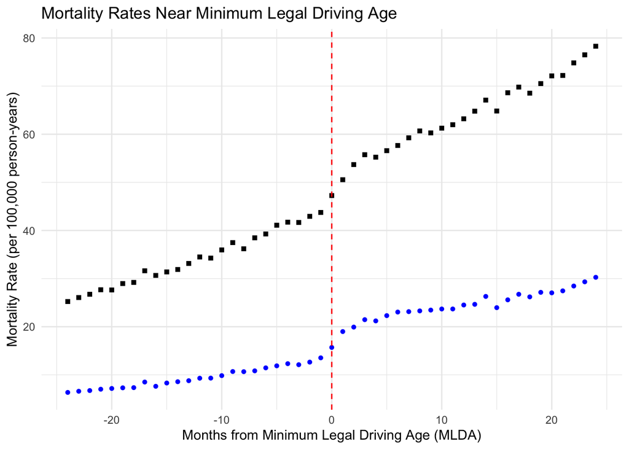

```r
# Create scatter plot
ggplot(data_in2years, aes(x = agemo_mda)) +
  # Use black squares to represent mortality rates from any cause
  geom_point(aes(y = death_rate_any), shape = 15, color = "black") +
  # Use blue circles to represent mortality rates from motor vehicle accidents
  geom_point(aes(y = death_rate_mva), shape = 16, color = "blue") +
  # Add a vertical line to represent the age at which driving eligibility begins
  geom_vline(xintercept = 0, linetype = "dashed", color = "red") +
  # Set plot title and axis labels
  labs(title = "Mortality Rates Near Minimum Legal Driving Age",
       x = "Months from Minimum Legal Driving Age (MLDA)",
       y = "Mortality Rate (per 100,000 person-years)") +
  # Set plot style
  theme_minimal() +
  theme(legend.position = "none")  # Hide legend
```

## 3 Non-Parametric “Donut” Regression Discontinuity Design (RD): Estimating Mortality Effects and Bandwidth Analysis

3. Non-parametric “donut” RD. Calculate a non-parametric RD estimated effect of driving on mortality rates due to (a) any cause and (b) motor vehicle accidents. Calculate these estimates using four different bandwidths: 48, 24, 12, and 6 months. Omit the partially-treated observation `agemo_mda==0` from the estimation to generate what is called a “donut” RD. Use linear regression to calculate all these values, and report and describe this equation in your answer below. Report the results in a three-column table with 4 rows (one row per bandwidth). Column (1) should report the bandwidth, column (2) the RD estimate for all-cause mortality, and column (3) the RD estimate for motor vehicle accident mortality. Discuss whether/why point estimates and their precision change as the bandwidth becomes smaller.

### 3.1 # Calculate mortality rates

```r
data <- data %>%
  mutate(rate_any_cause = 100000 * cod_any / (pop / 12),
         rate_motor_vehicle = 100000 * cod_MVA / (pop / 12),
         above_mlda = ifelse(agemo_mda > 0, 1, 0))

# Exclude partially treated observations
data_donut <- data %>% filter(agemo_mda != 0)
```

### 3.2 Define a function to calculate RD estimates

```r
calculate_rd <- function(data, bandwidth) {
  # Filter data within the bandwidth
  subset_data <- data %>% filter(abs(agemo_mda) <= bandwidth)

  # Linear regression for any cause mortality
  model_any <- lm(rate_any_cause ~ above_mlda, data = subset_data)
  rd_any <- coef(summary(model_any))["above_mlda", 1]

  # Linear regression for motor vehicle mortality
  model_mva <- lm(rate_motor_vehicle ~ above_mlda, data = subset_data)
  rd_mva <- coef(summary(model_mva))["above_mlda", 1]

  # Return RD estimates
  data.frame(
    Bandwidth = bandwidth,
    RD_All_Cause = rd_any,
    RD_MVA = rd_mva
  )
}
```

### 3.3 Calculate RD estimates for all bandwidths

```r
bandwidths <- c(48, 24, 12, 6)
results <- lapply(bandwidths, calculate_rd, data = data_donut)
# Combine results into a data frame
results_df <- do.call(rbind, results)
```

### 3.4 Create a table with results

First Column: Age ranges (bandwidths) of 48, 24, 12, and 6 months. Second Column: RD estimates for mortality due to any cause. Third Column: RD estimates for mortality due to motor vehicle accidents.

```r
results_df
```

```
##   Bandwidth RD_All_Cause    RD_MVA
## 1        48     48.83893 21.445071
## 2        24     30.27784 15.290869
## 3        12     19.06807 11.178446
## 4         6     13.16966  8.835371
```

## 4 Parametric “Donut” Regression Discontinuity Design (RD): Estimating Mortality Effects and Bandwidth Analysis Comparison

4. Parametric “donut” RD. Calculate a parametric RD estimated effect of driving on mortality rates due to (a) any cause and (b) motor vehicle accidents. Allow for linear trends on either side of the cutoff. Calculate these estimates using four different bandwidths: 48, 24, 12, and 6 months. Omit the partially-treated observation `agemo_mda==0` from the estimation to perform a “donut” RD. Use linear regression to calculate all these values, and report and describe this equation in your answer below. Report the results in a three-column table with 4 rows (one row per bandwidth). Column (1) should report the bandwidth, column (2) the RD estimate for all-cause mortality, and column (3) the RD estimate for motor vehicle accident mortality. Discuss whether/why point estimates and theirprecision change as the bandwidth becomes smaller. How do these parametric estimates compare to the non-parametric RD estimates?

Answer: As the bandwidth narrows, point estimates for all-cause and MVA mortality decrease, reflecting reduced bias from distant observations. For example, all-cause mortality drops from 11.89 at 48 months to 6.01 at 6 months. However, smaller bandwidths reduce sample size, increasing standard errors and lowering precision, highlighting the trade-off between bias reduction and estimate reliability.

### 4.1 Remove Partially Treated Observations

```r
# Exclude `agemo_mda == 0` for "donut" RD
data_no0 <- data %>% filter(agemo_mda != 0)
```

### 4.2 Parametric Donut RD Analysis

```r
# Define the bandwidths and initialize results
bandwidths <- c(48, 24, 12, 6)
parametric_results <- data.frame(
  Bandwidth = numeric(),
  RD_AllCause = numeric(),
  RD_MVA = numeric()
)
```

### 4.3 Loop through Bandwidths and Perform Regression

```r
for (bw in bandwidths) {
  # **5.3.1 Filter and Prepare Data for the Given Bandwidth**
  data_bandwidth <- data_no0 %>%
    filter(agemo_mda >= -bw & agemo_mda <= bw) %>%
    mutate(
      # Standardize mortality rates (per 100,000 population)
      death_rate_any = 100000 * cod_any / (pop / 12),
      death_rate_mva = 100000 * cod_MVA / (pop / 12),
      # Create treatment indicator
      treatment = ifelse(agemo_mda > 0, 1, 0)
    )

  # **5.3.2 Linear Regression Models**
  # All-cause mortality with interaction term
  model_allcause <- lm(
    death_rate_any ~ treatment + agemo_mda + treatment:agemo_mda,
    data = data_bandwidth
  )

  # Motor vehicle accident mortality with interaction term
  model_mva <- lm(
    death_rate_mva ~ treatment + agemo_mda + treatment:agemo_mda,
    data = data_bandwidth
  )

  # **5.3.3 Extract RD Estimates**
  rd_allcause <- coef(summary(model_allcause))["treatment", "Estimate"]
  rd_mva <- coef(summary(model_mva))["treatment", "Estimate"]

  # **5.3.4 Append Results**
  parametric_results <- rbind(
    parametric_results,
    data.frame(Bandwidth = bw, RD_AllCause = rd_allcause, RD_MVA = rd_mva)
  )
}
```

### 4.4 Output Results

```r
# Generate a formatted table of RD estimates
kable(
  parametric_results,
  col.names = c("Bandwidth (Months)", "RD Estimate (All-Cause Mortality)", "RD Estimate (MVA Mortality)"),
  caption = "Parametric Donut RD Estimates with Linear Trends"
)
```

Parametric Donut RD Estimates with Linear Trends

| Bandwidth (Months) | RD Estimate (All-Cause Mortality) | RD Estimate (MVA Mortality) |
| --- | --- | --- |
| 48 | 11.891433 | 9.534183 |
| 24 | 6.877585 | 6.551764 |
| 12 | 6.611472 | 5.968510 |
| 6 | 6.012612 | 4.867183 |

[output not shown]